# Statistica Medica — Corrado Lanera – Statistica Medica

[figure not shown]

[figure not shown]

[figure not shown]


# Statistica Medica

Inferenza, intervalli di confidenza, introduzione ai test d’ipotesi

Corrado Lanera

[Unità di Biostatistica, Epidemiologia e Salute Pubblica](https://www.unipd-ubep.it/), Università di Padova

11 novembre 2026

## Cosa faremo

In questa lezione ci occuperemo di **stime** effettuate su **campioni** di popolazioni. In questo senso, cercheremo di capire come **stimare la media** e la **varianza** partendo da un campione.

In seguito ci occuperemo di capire come avere una misura di **precisione** per queste stime, introducendo gli **Intervalli di confidenza**.

Dopo aver proposto degli esempi e fatto qualche osservazione in merito, introdurremo la distribuzione **t di Student**, utile quando la varianza della popolazione non è nota.

Introdurremo quindi il concetto di **test d’ipotesi**, delle tipologie di errore, e di **p-value**. Vedremo quindi come questi concetti si legano a quello degli intervalli di confidenza, e come leggere un p-value in un articolo.

## Riconoscimenti

- Le diapositive proposte sono state prodotte a partire anche da materiale generato da/con le seguenti persone gravitanti attorno all’UBEP*:
  - Danila Azzolina
  - Dario Gregori
  - Giulia Lorenzoni
  - Ileana Baldi
  - Luca Vedovelli
  - Matteo Martinato
  - Paola Berchialla

* In ordine alfabetico.

> Un ringraziamento speciale a Cristiana Vettori e a Mariasole Rizzi per l’aiuto e il supporto logistico e amministrativo che mi è stato offerto, e ad Andrea Francavilla per avermi aiutato nella revisione del materiale.

## **Panoramica**

Definizione e caratteristiche del **problema inferenziale**

Stime puntuali: media e varianza… della media! **Teorema del limite centrale**

Precisione delle stime puntuali: **Intervalli di confidenza**

**Esempi** e **osservazioni**

Distribuzione **t di Student**

**Test d’ipotesi**: errori del I e II tipo, **p-value**

Relazione tra p-value e IC; come leggere un p-value

## **inferenza**

- **definizione**
- **campioni e popolazione**

## Inferenza: di cosa si tratta

Dato un insieme di osservazioni definito **campione**, si vuole derivare una conoscenza della distribuzione di probabilità che ha generato i dati osservati (generalmente per estrapolare informazioni sulle *non-osservazioni* della stessa popolazione)

## Inferenza: campioni e popolazioni

- Un campione casuale è una **selezione** di alcuni membri di una popolazione tale che ogni membro è scelto **indipendentemente** dagli altri ed ha una **probabilità non nulla** di essere selezionato
- Un campione casuale **semplice** è un campione casuale in cui ogni membro ha la **stessa probabilità** di essere selezionato
- La **popolazione target** è il gruppo di soggetti, **da cui è estratto** il campione, che si intende studiare e che **si ipotizza essere infinita**

## Mappa: Inferenza

- Mappa
- Indice

```
%%{init: {"htmlLabels": false, "flowchart": {"padding": 12, "wrappingWidth": 320}, "themeVariables": {"fontFamily": "Arial, Helvetica, sans-serif"}}}%%
flowchart LR
  k_n_02_unita["Unità, variabili, tabelle · 02"]:::prev
  k_n_03_probabilita["Probabilità · 03"]:::prev
  k_n_03_somma_prodotto["Somma, prodotto, indipendenza · 03"]:::prev
  k_n_04_massa["Massa e cumulata · 04"]:::prev
  n_inferenza_statistica["Inferenza"]:::cur
  n_campione_casuale["Campione casuale"]:::cur
  n_campione_casuale_semplice["Campione casuale semplice"]:::cur
  n_popolazione_target["Popolazione target"]:::cur
  k_n_02_unita --> n_campione_casuale
  k_n_02_unita --> n_inferenza_statistica
  k_n_03_probabilita --> n_campione_casuale
  k_n_03_somma_prodotto --> n_campione_casuale
  k_n_04_massa --> n_inferenza_statistica
  n_campione_casuale --> n_campione_casuale_semplice
  classDef cur fill:#e6f0fa,stroke:#035AA6,color:#000000
  classDef prev fill:#f4f4f4,stroke:#9a9a9a,color:#555555,stroke-dasharray:4 3
  classDef opt fill:#ffffff,stroke:#035AA6,color:#555555,stroke-dasharray:2 2
```

Ogni freccia va da un concetto a quelli che lo usano. In grigio i concetti delle sezioni o dei deck precedenti (con il numero del deck).

- Inferenza
- Campione casuale
- Campione casuale semplice
- Popolazione target

## Stime **puntuali** e **teorema del limite centrale**

- Stimatore puntuale della **media**
- **Errore standard** della media
- **Teorema del Limite Centrale** (TLC)

## Stima puntuale: media

Lo **stimatore puntuale** della media di una distribuzione è

$$\bar{X} = \frac{\sum_{i=1}^n X_i}{n}$$

La distribuzione campionaria di $\bar{X}$ è la distribuzione dei valori di $\bar{X}$ su **tutti i possibili campioni** di ampiezza $n$ estratti dalla popolazione target.

Se $X_1, \ldots, X_n$ è un campione casuale estratto da una popolazione con **media di popolazione** $\mu$ allora per la media campionaria vale $E(\bar{X}) = \mu$

Si dice che la media campionaria è uno **stimatore non distorto** della media di popolazione.

## Stima puntuale: errore standard

Riguardo alla **varianza** dello stimatore della media, abbiamo

$$\begin{split}\mbox{var}(\bar{X})&= \mbox{var}\left(\frac{\sum_{i=1}^n X_i}{n}\right) =* \frac{1}{n^2} \mbox{var}\left(\sum_{i=1}^n X_i\right) \stackrel{\mbox{ind.}}{=} \frac{1}{n^2} \sum_{i=1}^n \mbox{var}(X_i)\\& \stackrel{\mbox{def}}{=} \frac{1}{n^2} \sum_{i=1}^n\sigma^2 = \frac{1}{n^2} n\sigma^2 = \frac{\sigma^2}{n}\end{split}$$

- $\frac{\sigma}{\sqrt{n}}$ è chiamato errore standard della media, stimato da $\frac{s}{\sqrt{n}}$
- il passaggio $\stackrel{\mbox{ind.}}{=}$ vale perché le $X_i$ sono **indipendenti**

$$*)\begin{split}\mbox{var}(aX) &= \frac{\sum_1^n\left(ax_i-\frac{\sum_1^nax_j}{n}\right)^2}{n}= \frac{\sum_1^n\left(ax_i-\frac{a\sum_1^nx_j}{n}\right)^2}{n}\\&= \frac{\sum_1^n\left(a\left(x_i-\mu\right)\right)^2}{n}= \frac{\sum_1^na^2\left(x_i-\mu\right)^2}{n}\\&=\frac{a^2\sum_1^n\left(x_i-\mu\right)^2}{n}=a^ 2\mbox{var}(X)\end{split}$$

Una costante esce dalla sommatoria: $\sum_i C x_i = C\sum_i x_i$.

## Teorema del Limite Centrale

**Sia**

- $X_1, \ldots, X_n$ un campione casuale semplice estratto da una popolazione qualsiasi con media $\mu$ e varianza $\sigma^2$.

**Allora**, per $n$ abbastanza grande:

$$\bar{X} \sim N \left( \mu, \frac{\sigma^2}{n} \right)$$

> … anche se la distribuzione $X$ della popolazione non è normale!

## Sondaggio

Per me: [Stimatore della media](https://app.wooclap.com/events/STATMEDTLC/0)

Per voi:

[figure not shown]

bit.ly/statmed-sondaggio-tlc

## Mappa: Stime puntuali

- Mappa
- Indice

```
%%{init: {"htmlLabels": false, "flowchart": {"padding": 12, "wrappingWidth": 320}, "themeVariables": {"fontFamily": "Arial, Helvetica, sans-serif"}}}%%
flowchart LR
  n_campione_casuale_semplice["Campione casuale semplice"]:::prev
  n_popolazione_target["Popolazione target"]:::prev
  k_n_02_centralita["Centralità · 02"]:::prev
  k_n_02_notazioni["Indici e sommatoria · 02"]:::prev
  k_n_02_unita["Unità, variabili, tabelle · 02"]:::prev
  k_n_02_variabilita["Variabilità · 02"]:::prev
  k_n_04_massa["Massa e cumulata · 04"]:::prev
  k_n_04_momenti["Valore atteso e varianza · 04"]:::prev
  k_n_04_normale["Normale · 04"]:::prev
  k_n_04_parametri["Parametri e statistiche · 04"]:::prev
  k_n_04_vc["Variabili casuali · 04"]:::prev
  n_stima_puntuale["Stima puntuale"]:::cur
  n_stimatore["Stimatore"]:::cur
  n_numerosita_campionaria["Numerosità n"]:::cur
  n_distribuzione_campionaria["Distribuzione campionaria"]:::cur
  n_stimatore_non_distorto["Stimatore non distorto"]:::cur
  n_varianza_di_trasformazione_lineare["Var(aX)"]:::cur
  n_varianza_della_media_campionaria["Varianza della media"]:::cur
  n_errore_standard["Errore standard"]:::cur
  n_teorema_del_limite_centrale["Limite centrale"]:::cur
  k_n_02_centralita --> n_stimatore
  k_n_02_notazioni --> n_stimatore
  k_n_02_unita --> n_numerosita_campionaria
  k_n_02_unita --> n_stima_puntuale
  k_n_02_variabilita --> n_errore_standard
  k_n_04_massa --> n_distribuzione_campionaria
  k_n_04_momenti --> n_stimatore_non_distorto
  k_n_04_momenti --> n_varianza_di_trasformazione_lineare
  k_n_04_normale --> n_teorema_del_limite_centrale
  k_n_04_parametri --> n_stima_puntuale
  k_n_04_vc --> n_distribuzione_campionaria
  k_n_04_vc --> n_stimatore
  n_campione_casuale_semplice --> n_teorema_del_limite_centrale
  n_distribuzione_campionaria --> n_teorema_del_limite_centrale
  n_numerosita_campionaria --> n_distribuzione_campionaria
  n_numerosita_campionaria --> n_varianza_della_media_campionaria
  n_popolazione_target --> n_distribuzione_campionaria
  n_stima_puntuale --> n_stimatore
  n_stimatore --> n_stimatore_non_distorto
  n_stimatore --> n_varianza_della_media_campionaria
  n_varianza_della_media_campionaria --> n_errore_standard
  n_varianza_della_media_campionaria --> n_teorema_del_limite_centrale
  n_varianza_di_trasformazione_lineare --> n_varianza_della_media_campionaria
  classDef cur fill:#e6f0fa,stroke:#035AA6,color:#000000
  classDef prev fill:#f4f4f4,stroke:#9a9a9a,color:#555555,stroke-dasharray:4 3
  classDef opt fill:#ffffff,stroke:#035AA6,color:#555555,stroke-dasharray:2 2
```

Ogni freccia va da un concetto a quelli che lo usano. In grigio i concetti delle sezioni o dei deck precedenti (con il numero del deck).

- Stima puntuale
- Stimatore
- Numerosità n
- Distribuzione campionaria
- Stimatore non distorto
- Var(aX)
- Varianza della media
- Errore standard
- Limite centrale

## **Precisione** delle stime

- **Intervalli di Confidenza**
- **Ampiezza** dell’intervallo di confidenza

## Intervalli di Confidenza: Obiettivo

Associare alla stima puntuale una misura della sua precisione

## I.C.: Derivazione

- Passaggio a Z
- Ritorno alle stime
- Conclusione

Se $X$ è normale (oppure, per il T.L.C., se $n$ è abbastanza grande, e in questo caso in modo approssimato) sappiamo che

$$Z =\frac{\bar{X}-\mu}{\frac{\sigma}{\sqrt{n}}}$$

si distribuisce come una variabile casuale normale standardizzata $Z \sim N(0,1)$

In questo caso, il 95% delle osservazioni è compreso tra -1.96 e 1.96, ovvero

$$\mbox{P}(-1.96\leq Z\leq 1.96)= 0.95$$

Sostituendo alla $Z$ la sua espressione estesa

$$P \left (-1.96 \leq \frac{\bar{X}-\mu}{\frac{\sigma}{\sqrt{n}}}
\leq 1.96 \right ) = 0.95$$

Moltiplicando tutti i termini per ${\frac{\sigma}{\sqrt{n}}}$

$$P \left (-1.96 {\frac{\sigma}{\sqrt{n}}} \leq
\frac{\bar{X}-\mu}{\frac{\sigma}{\sqrt{n}}}
{\frac{\sigma}{\sqrt{n}}}\leq 1.96 {\frac{\sigma}{\sqrt{n}}}\right
) = 0.95$$

Semplificando

$$P \left (-1.96 {\frac{\sigma}{\sqrt{n}}} \leq \bar{X}-\mu\leq 1.96
{\frac{\sigma}{\sqrt{n}}}\right ) = 0.95$$

$$P \left (-1.96 {\frac{\sigma}{\sqrt{n}}} \leq \bar{X}-\mu\leq 1.96
{\frac{\sigma}{\sqrt{n}}}\right ) = 0.95$$

Sottraendo $\bar{X}$ da ogni termine

$$P \left (-1.96 {\frac{\sigma}{\sqrt{n}}}-\bar{X} \leq \bar{X}-\mu
-\bar{X}\leq 1.96 {\frac{\sigma}{\sqrt{n}}-\bar{X}}\right ) = 0.95$$

Moltiplicando per -1 ed invertendo il senso delle disugualianze

$$P \left (1.96 {\frac{\sigma}{\sqrt{n}}}+\bar{X} \geq \mu \geq
-1.96 {\frac{\sigma}{\sqrt{n}}+\bar{X}}\right ) = 0.95$$

Riorganizzando i termini

$$P \left (\bar{X} - 1.96 {\frac{\sigma}{\sqrt{n}}}\leq \mu \leq
\bar{X}+1.96 {\frac{\sigma}{\sqrt{n}}}\right )= 0.95$$

## Definizione I.C. per la media (varianza nota)

Un intervallo di confidenza al 95% per $\mu$ **quando $\sigma^2$ è noto** è dato da

$$\left ( \bar{X} - 1.96 \frac{\sigma}{\sqrt{n}}; \bar{X} + 1.96
\frac{\sigma}{\sqrt{n}} \right )$$

## Sondaggio

Per me: [Intervalli di Confidenza](https://app.wooclap.com/events/STATMEDICP/0)

Per voi:

[figure not shown]

bit.ly/statmed-sondaggio-icp

## Mappa: Precisione delle stime

- Mappa
- Indice

```
%%{init: {"htmlLabels": false, "flowchart": {"padding": 12, "wrappingWidth": 320}, "themeVariables": {"fontFamily": "Arial, Helvetica, sans-serif"}}}%%
flowchart LR
  n_errore_standard["Errore standard"]:::prev
  n_stima_puntuale["Stima puntuale"]:::prev
  n_stimatore["Stimatore"]:::prev
  n_teorema_del_limite_centrale["Limite centrale"]:::prev
  k_n_03_probabilita["Probabilità · 03"]:::prev
  k_n_04_normale["Normale · 04"]:::prev
  k_n_04_tavole["Tavole e standardizzazione · 04"]:::prev
  n_intervallo_di_confidenza["Intervallo di confidenza"]:::cur
  n_derivazione_ic_con_z["Derivazione dell'IC"]:::cur
  n_ic_media_varianza_nota["IC, σ nota"]:::cur
  k_n_03_probabilita --> n_derivazione_ic_con_z
  k_n_03_probabilita --> n_intervallo_di_confidenza
  k_n_04_normale --> n_derivazione_ic_con_z
  k_n_04_tavole --> n_derivazione_ic_con_z
  n_derivazione_ic_con_z --> n_ic_media_varianza_nota
  n_errore_standard --> n_derivazione_ic_con_z
  n_intervallo_di_confidenza --> n_ic_media_varianza_nota
  n_stima_puntuale --> n_intervallo_di_confidenza
  n_stimatore --> n_ic_media_varianza_nota
  n_teorema_del_limite_centrale --> n_derivazione_ic_con_z
  classDef cur fill:#e6f0fa,stroke:#035AA6,color:#000000
  classDef prev fill:#f4f4f4,stroke:#9a9a9a,color:#555555,stroke-dasharray:4 3
  classDef opt fill:#ffffff,stroke:#035AA6,color:#555555,stroke-dasharray:2 2
```

Ogni freccia va da un concetto a quelli che lo usano. In grigio i concetti delle sezioni o dei deck precedenti (con il numero del deck).

- Intervallo di confidenza
- Derivazione dell’IC
- IC, σ nota

## Break

Consigli:

- alzarsi
- sgranchirsi
- guardare *lontano* (rilassare gli occhi)
- bere
- andare in bagno

## **Esempi** e **Osservazioni**

- **esempio** con i trigliceridi
- **confidenza**, **unicità** e **ampiezza** dell’intervallo

## I.C.: Trigliceridi

- Problema
- IC
- Graficamente

| Soggetto | 1 | 2 | 3 | 4 | 5 |
| --- | --- | --- | --- | --- | --- |
| 1 | 97 | 177 | 97 | 101 | 137 |
| 2 | 117 | 198 | 125 | 114 | 118 |
| 3 | 140 | 107 | 62 | 79 | 78 |
| 4 | 78 | 99 | 120 | 120 | 129 |
| 5 | 99 | 104 | 132 | 115 | 87 |
| 6 | 148 | 121 | 135 | 117 | 110 |
| 7 | 108 | 148 | 118 | 106 | 106 |
| 8 | 135 | 133 | 137 | 86 | 116 |
| 9 | 126 | 126 | 126 | 110 | 140 |
| 10 | 121 | 115 | 118 | 119 | 98 |
| $\bar{x}$ | 116.9 | 132.8 | 117.0 | 106.7 | 111.9 |
| $s$ | 21.70 | 32.62 | 22.44 | 14.13 | 20.46 |

Cinque campioni casuali di ampiezza ($n = 10$) da una popolazione di soggetti afferenti al centro cardiovascolare dell’ASL 1 di Trieste, a cui è stato rilevato il livello di trigliceridi (in mg/dl, valori di riferimento 50-175).

Si supponga che il valore di $\sigma$ sia noto e pari a 20.

$$\begin{split}\left(\bar{X} - 1.96 \frac{\sigma}{\sqrt{n}}; \bar{X}+1.96 \frac{\sigma}{\sqrt{n}} \right)&= \left (\bar{X}-1.96\frac{20}{\sqrt{10}}; \bar{X} + 1.96 \frac{20}{\sqrt{10}} \right)\\& = (\bar{X}-12.4; \bar{X}+12.4)\end{split}$$

- Campione 1 $(116.9-12.4; 116.9+12.4) \equiv (104.5; 129.3)$
- Campione 2 $(132.8-12.4; 132.8+12.4) \equiv (120.4; 145.2)$
- Campione 3 $(117.0-12.4; 117.0+12.4) \equiv (104.6; 129.4)$
- Campione 4 $(106.7-12.4; 106.7+12.4) \equiv (94.3; 119.1)$
- Campione 5 $(111.9-12.4; 111.9+12.4) \equiv (99.5; 124.3)$

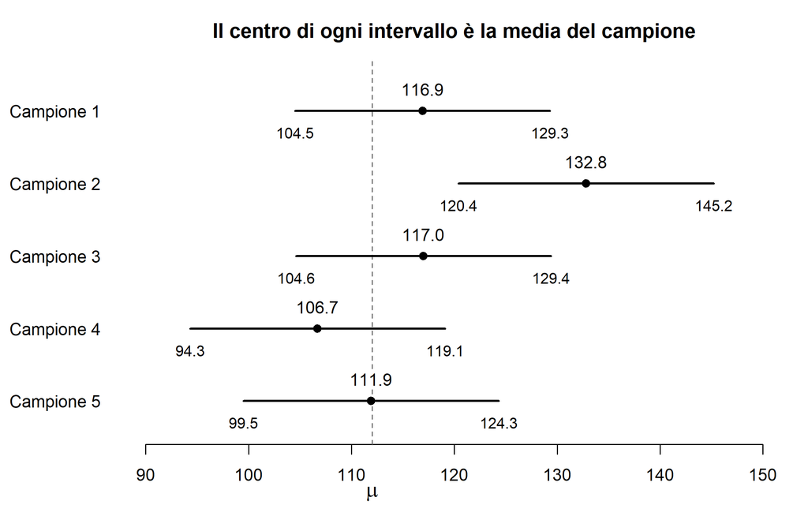

## IC osservazioni: “confidenza”

**$\bar{X}$ è una variabile casuale**, mentre il parametro **$\mu$ è una costante** (ignota). Quindi l’intervallo

$$\left ( \bar{X} - 1.96 \frac{\sigma}{\sqrt{n}}; \bar{X} + 1.96 \frac{\sigma}{\sqrt{n}} \right )$$

ha una probabilità del 95% di comprendere $\mu$ **prima** che il campione sia selezionato.

**Dopo aver selezionato il campione** e aver calcolato l’intervallo, invece:

- $\mu$ può essere compresa o meno nell’intervallo (non lo sappiamo)
- stimiamo che su 100 campioni estratti dalla stessa popolazione, circa 95 conterranno la media **e 5 no** (ed utilizziamo di conseguenza il termine di **confidenza**)

> NOTA: uno dei 5 **potrebbe essere il nostro**!!

In ogni caso, l’interpretazione è corretta se il campione selezionato è un campione **rappresentativo** (non distorto) della popolazione studiata

## IC osservazioni: unicità

- Osservazione
- Trigliceridi

L’intervallo di confidenza al 95% è quello di uso più comune, ma non è l’unico.

In generale, un intervallo di confidenza ad un livello $(1-\alpha)$ sarà dato da

$$\left ( \bar{x} - z_{1-\frac{\alpha}{2}} \frac{\sigma}{\sqrt{n}};
\bar{x} + z_{1-\frac{\alpha}{2}} \frac{\sigma}{\sqrt{n}} \right )$$

dove $z_{1-\frac{\alpha}{2}}$ è il $100(1-\frac{\alpha}{2})$-esimo percentile di una distribuzione $N(0,1)$.

$\alpha$ è la probabilità, prima di estrarre il campione, che l’intervallo non contenga $\mu$.

| $(1-\alpha)$ | 0.90 | 0.95 | 0.99 |
| --- | --- | --- | --- |
| $z_{1-\frac{\alpha}{2}}$ | 1.645 | 1.96 | 2.576 |

Nel caso del primo campione selezionato, si ha che un intervallo al 99% è pari a

$$\begin{split} &\left(116.9 - z_{0.995} \frac{20}{\sqrt{10}}; 116.9 + z_{0.995} \frac{20}{\sqrt{10}} \right)\\ = &\left(116.9- 2.576\frac{20}{\sqrt{10}}; 116.9+2.576\frac{20}{\sqrt{10}}\right)\\ = &(100.6; 133.2)\end{split}$$

## IC osservazioni: ampiezza

- Constatazione
- Osservazione
- Trigliceridi

L’**ampiezza** dell’intervallo di confidenza a un livello $(1-\alpha)$ è data da

$$\bar{X}+z_{1-\frac{\alpha}{2}} \frac{\sigma}{\sqrt{n}} - \left(\bar{X} - z_{1-\frac{\alpha}{2}} \frac{\sigma}{\sqrt{n}} \right )$$

ovvero da

$$2 z_{1-\frac{\alpha}{2}} \frac{\sigma}{\sqrt{n}}$$

Nel campione 1, l’ampiezza (al 95% e con $\sigma = 20$) è pari a

$$2 \times 1.96 \frac{20}{\sqrt{10}} = 24.8 = 129.3-104.5$$

L’ampiezza dell’intervallo, data da $2 z_{1-\frac{\alpha}{2}} \frac{\sigma}{\sqrt{n}}$

**dipende da**

- $n$: come **cresce** il campione ($n$), così **diminuisce** l’ampiezza dell’intervallo
- $\sigma$: come **aumenta** la deviazione standard della popolazione ($\sigma$), così **aumenta** l’ampiezza dell’intervallo
- $1-\alpha$: come **aumenta** il livello di confidenza richiesto per l’analisi, così **aumenta** l’ampiezza dell’intervallo

Per l’intervallo del campione 1, pari a (104.5; 129.3) con $n=10$, $\sigma=20$, $1-\alpha=0.95$

| $n$ | $\sigma$ | $1-\alpha$ | Limiti | Ampiezza |
| --- | --- | --- | --- | --- |
| n | 20 | 0.95 | $\bar{X} \pm 1.96 \frac{20}{\sqrt{n}}$ |  |
| 10 | 20 | 0.95 |  | 24.8 |
| 100 | 20 | 0.95 |  | 7.8 |
| 1000 | 20 | 0.95 |  | 2.5 |
| 10 | $\sigma$ | 0.95 | $\bar{X} \pm 1.96 \frac{\sigma}{\sqrt{10}}$ |  |
| 10 | 5 | 0.95 |  | 6.2 |
| 10 | 40 | 0.95 |  | 49.6 |
| 10 | 20 | $1-\alpha$ | $\bar{X} \pm z_{1-\frac{\alpha}{2}} \frac{20}{\sqrt{10}}$ |  |
| 10 | 20 | 0.90 |  | 20.8 |
| 10 | 20 | 0.95 |  | 24.8 |
| 10 | 20 | 0.99 |  | 32.6 |

## IC osservazioni: sotto controllo

$n$ e $\alpha$ sono **sotto il diretto controllo** del ricercatore

$\sigma$, ovvero la variabilità a livello di popolazione, **dipende dal tipo di variabile** studiata.

In alcuni casi e con opportuni accorgimenti **può essere controllata**, con:

- scelta di tecniche per **misurazioni più accurate**
- scelta del **timing di misurazione** ottimale per ridurre la variabilità, per es. giornaliera
- utilizzo di tecniche di **mediazione**, ottenendo varie misurazioni ripetute sulla stessa variabile e utilizzando la media di queste anziché una singola osservazione nel calcolo dell’intervallo

## Mappa: Esempi e osservazioni

- Mappa
- Indice

```
%%{init: {"htmlLabels": false, "flowchart": {"padding": 12, "wrappingWidth": 320}, "themeVariables": {"fontFamily": "Arial, Helvetica, sans-serif"}}}%%
flowchart LR
  n_distribuzione_campionaria["Distribuzione campionaria"]:::prev
  n_errore_standard["Errore standard"]:::prev
  n_ic_media_varianza_nota["IC, σ nota"]:::prev
  n_intervallo_di_confidenza["Intervallo di confidenza"]:::prev
  k_n_02_unita["Unità, variabili, tabelle · 02"]:::prev
  k_n_03_probabilita["Probabilità · 03"]:::prev
  k_n_04_parametri["Parametri e statistiche · 04"]:::prev
  k_n_04_tavole["Tavole e standardizzazione · 04"]:::prev
  k_n_04_vc["Variabili casuali · 04"]:::prev
  n_livello_di_confidenza["Livello di confidenza"]:::cur
  n_interpretazione_dell_intervallo_di_confidenza["Interpretazione dell'IC"]:::cur
  n_campione_rappresentativo["Campione rappresentativo"]:::cur
  n_ic_a_livello_generico["IC a livello 1−α"]:::cur
  n_ampiezza_dell_intervallo_di_confidenza["Ampiezza dell'IC"]:::cur
  n_controllo_della_variabilita_di_misura["Precisione delle misure"]:::cur
  k_n_02_unita --> n_campione_rappresentativo
  k_n_03_probabilita --> n_interpretazione_dell_intervallo_di_confidenza
  k_n_04_parametri --> n_interpretazione_dell_intervallo_di_confidenza
  k_n_04_tavole --> n_ic_a_livello_generico
  k_n_04_vc --> n_interpretazione_dell_intervallo_di_confidenza
  n_ampiezza_dell_intervallo_di_confidenza --> n_controllo_della_variabilita_di_misura
  n_distribuzione_campionaria --> n_livello_di_confidenza
  n_errore_standard --> n_ampiezza_dell_intervallo_di_confidenza
  n_ic_a_livello_generico --> n_ampiezza_dell_intervallo_di_confidenza
  n_ic_media_varianza_nota --> n_ic_a_livello_generico
  n_intervallo_di_confidenza --> n_livello_di_confidenza
  n_livello_di_confidenza --> n_ic_a_livello_generico
  n_livello_di_confidenza --> n_interpretazione_dell_intervallo_di_confidenza
  classDef cur fill:#e6f0fa,stroke:#035AA6,color:#000000
  classDef prev fill:#f4f4f4,stroke:#9a9a9a,color:#555555,stroke-dasharray:4 3
  classDef opt fill:#ffffff,stroke:#035AA6,color:#555555,stroke-dasharray:2 2
```

Ogni freccia va da un concetto a quelli che lo usano. In grigio i concetti delle sezioni o dei deck precedenti (con il numero del deck).

- Livello di confidenza
- Interpretazione dell’IC
- Campione rappresentativo
- IC a livello 1−α
- Ampiezza dell’IC
- Precisione delle misure

## Distribuzione **t di Student**

- **t di Student**
- **I.C.**

## Distribuzione t di Student

- Definizione
- Percentili
- Grafico

Se $\sigma$ è **ignoto**, potremmo sostituirlo (approssimandolo/stimandolo) in $\frac{\bar{X}-\mu}{\frac{\sigma}{\sqrt{n}}}$ con $s$

**Se**

- $X_1, \ldots, X_n \sim N(\mu,\sigma^2)$
- sono indipendenti

**Allora**

- $\frac{\bar{X}-\mu}{\frac{s}{\sqrt{n}}}$ si distribuisce come una $t$ di Student con $(n-1)$ gradi di libertà

Il $p$ -esimo percentile della distribuzione $t$ con $d$ gradi di libertà si indica con $t_{d,p}$, ovvero

$$P(t_d \leq t_{d,p}) = p$$

> Nota: La distribuzione $t$ è simmetrica sullo $0$ ma è più dispersa rispetto alla $N(0,1)$

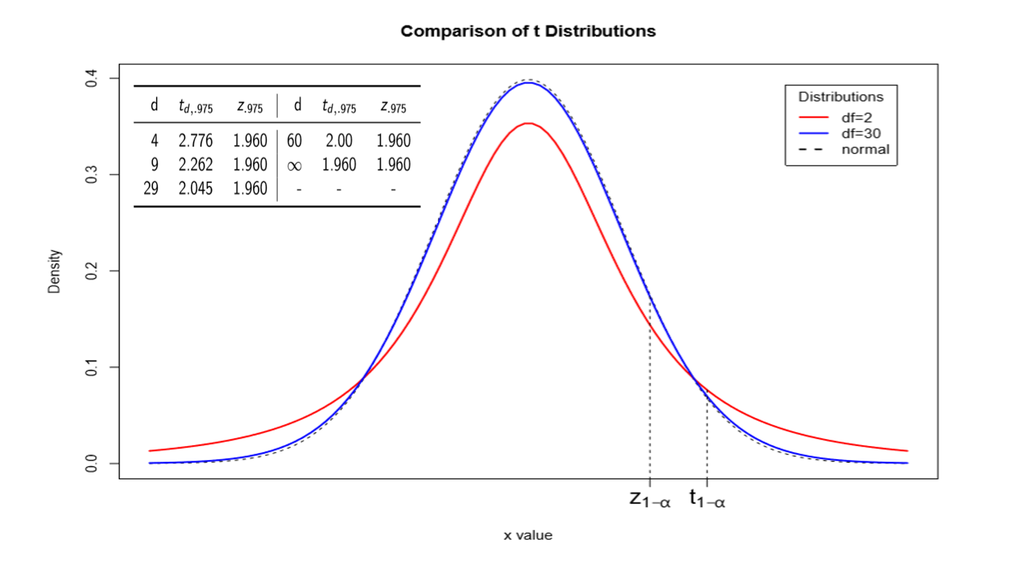

## IC per la media: varianza non nota

- Considerazione
- Definizione
- Trigliceridi

Nel caso di varianza stimata $S^2$, abbiamo appena visto che

$$T=\frac{\bar{X}-\mu}{\frac{s}{\sqrt{n}}} \sim t_{n-1} \:\:\: di\:\:\: Student$$

e per questa variabile si ha che, con ($n=10$, ovvero $d=9$ gradi di libertà )

$$\mbox{P}(-2.262\leq T\leq 2.262)= 0.95$$

ripercorrendo i passaggi del caso con varianza nota si ottiene che l’intervallo di confidenza al 95% è pari a

$$\left (\bar{x} -2.262 \frac{s}{\sqrt{10}} \leq \mu \leq \bar{x} + 2.262 \frac{s}{\sqrt{10}} \right )$$

In cui $2.262 = t_{9, 0.975} = t_{d,p}$ essendo $\alpha = 0.05$ e $p = 1-\frac{\alpha}{2} = 0.975$

Un intervallo di confidenza al 95% per $\mu$ quando $\sigma^2$ è ignoto è dato da

$$\left ( \bar{x} - t_{n-1,1-\frac{\alpha}{2}} \frac{s}{\sqrt{n}}; \bar{x} + t_{n-1,1-\frac{\alpha}{2}}
\frac{s}{\sqrt{n}} \right )$$

Nel caso del campione 1 si ha:

- $\bar{x} = 116.90$
- $n = 10$
- $s = 21.7$
- $\alpha = 0.05$

$$\left (116.90 -2.262 \frac{21.7}{\sqrt{10}} \leq \mu \leq 116.90 + 2.262 \frac{21.7}{\sqrt{10}} \right )$$

ovvero $(101.38; 132.42)$

In generale, si avrà l’intervallo

$$\left (\bar{x} - t_{n-1,1-\frac{\alpha}{2}} \frac{s}{\sqrt{n}} \leq \mu \leq \bar{x} + t_{n-1,1-\frac{\alpha}{2}} \frac{s}{\sqrt{n}} \right )$$

## Sondaggio

Per me: [Distribuzione t-Student](https://app.wooclap.com/events/STATMEDTSTUDENT/0)

Per voi:

[figure not shown]

bit.ly/statmed-sondaggio-tstudent

## Mappa: t di Student

- Mappa
- Indice

```
%%{init: {"htmlLabels": false, "flowchart": {"padding": 12, "wrappingWidth": 320}, "themeVariables": {"fontFamily": "Arial, Helvetica, sans-serif"}}}%%
flowchart LR
  n_numerosita_campionaria["Numerosità n"]:::prev
  n_stimatore["Stimatore"]:::prev
  n_ic_media_varianza_nota["IC, σ nota"]:::prev
  k_n_02_percentili["Percentili e quartili · 02"]:::prev
  k_n_02_variabilita["Variabilità · 02"]:::prev
  k_n_03_somma_prodotto["Somma, prodotto, indipendenza · 03"]:::prev
  k_n_04_normale["Normale · 04"]:::prev
  n_ic_media_varianza_ignota["IC, σ ignota"]:::cur
  n_distribuzione_t_di_student["t di Student"]:::cur
  n_gradi_di_liberta["Gradi di libertà"]:::cur
  n_percentile_della_t_di_student["Percentili di t"]:::cur
  k_n_02_percentili --> n_percentile_della_t_di_student
  k_n_02_variabilita --> n_distribuzione_t_di_student
  k_n_03_somma_prodotto --> n_distribuzione_t_di_student
  k_n_04_normale --> n_distribuzione_t_di_student
  n_distribuzione_t_di_student --> n_percentile_della_t_di_student
  n_gradi_di_liberta --> n_distribuzione_t_di_student
  n_ic_media_varianza_nota --> n_ic_media_varianza_ignota
  n_numerosita_campionaria --> n_gradi_di_liberta
  n_percentile_della_t_di_student --> n_ic_media_varianza_ignota
  n_stimatore --> n_distribuzione_t_di_student
  classDef cur fill:#e6f0fa,stroke:#035AA6,color:#000000
  classDef prev fill:#f4f4f4,stroke:#9a9a9a,color:#555555,stroke-dasharray:4 3
  classDef opt fill:#ffffff,stroke:#035AA6,color:#555555,stroke-dasharray:2 2
```

Ogni freccia va da un concetto a quelli che lo usano. In grigio i concetti delle sezioni o dei deck precedenti (con il numero del deck).

- IC, σ ignota
- t di Student
- Gradi di libertà
- Percentili di t

## **Test d’ipotesi**

- **Ipotesi ed errori**: $H_0$ e $H_1$, rifiuto e non rifiuto, errori di I e II tipo
- **Test z e test t**: valore critico, regione di rifiuto, una e due code
- **P-value**: relazione con l’IC e come leggerlo in un articolo

## Un problema: colesterolo e familiarità

- Quesito
- Grafico
- Problema
- Risposta

Si supponga che il livello di colesterolo (espresso in $mg/dL$) **medio** nei bambini di età compresa tra i 2 e i 14 anni sia noto, da ampi studi di popolazione, essere **pari a 175**, con una deviazione standard di 30.

Si vuole valutare la possibilità che vi sia un’aggregazione familiare dei livelli di colesterolo.

Si identifica un gruppo di padri con pregresso infarto del miocardio acuto (IMA) ed elevati livelli di colesterolo, e si misura il livello di colesterolo dei figli che abbiano un’età compresa nell’intervallo in esame.

**Il livello medio stimato nel campione di 100 figli è pari a 207.2.**

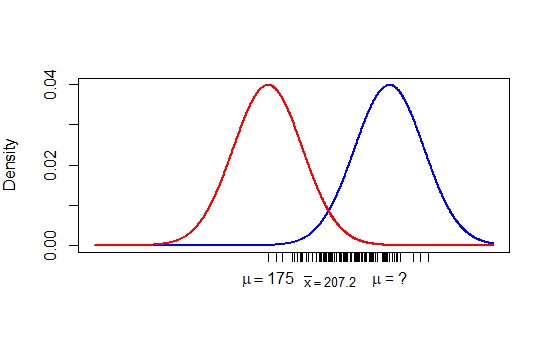

Questo valore ($207.2\ mg/dL$) è **sufficientemente lontano** da quello di $175\ mg/dL$ da farci credere che questi bambini abbiano una distribuzione dei livelli di colesterolo con una media più elevata di quella della popolazione generale dei bambini nella stessa classe di età?

Un intervallo di confidenza (bilaterale) al 95% per la media dei figli:

$$\left(207.2 - 1.96 \frac{30}{\sqrt{100}}; 207.2+1.96 \frac{30}{\sqrt{100}}\right) = (201.32; 213.08)$$

175 è fuori dall’IC al 95% (201.32; 213.08): tutti i valori di $\mu$ compatibili con i dati stanno sopra 200.

Quanto sarebbe raro un campione con media di 207.2 o più, se la media vera fosse 175? È la domanda a cui risponde il test d’ipotesi.

## Ipotesi: definizioni

Le ipotesi riguardano i **parametri** della popolazione (qui la media $\mu$), non il campione.

- **ipotesi nulla** $H_0$: l’ipotesi che si mette alla prova, di solito «nessuna differenza» dal valore di riferimento. Nell’esempio: $H_0: \mu = 175$
- **ipotesi alternativa** $H_1$: l’ipotesi che **contraddice** $H_0$. Nell’esempio: $H_1: \mu > 175$

Un **test d’ipotesi** è una regola che, a partire dai dati del campione, decide se **rifiutare** $H_0$ oppure **non rifiutarla**.

## Ipotesi: decisioni

| Decisione | $H_0$ **vera** | $H_0$ **falsa** |
| --- | --- | --- |
| **Non rifiuto** $H_0$ | Decisione corretta P = $1-\alpha$ | Errore di II tipo P = $\beta$ |
| **Rifiuto** $H_0$ | Errore di I tipo P = $\alpha$ | Decisione corretta P = $1-\beta$ |

- $\alpha = P(\mbox{rifiuto}\ H_0 \mid H_0\ \mbox{vera})$, errore di I tipo: è il livello di significatività del test. È lo stesso $\alpha$ dell’IC al livello $1-\alpha$: il legame si vede nella slide «P-value e IC».
- $\beta = P(\mbox{non rifiuto}\ H_0 \mid H_0\ \mbox{falsa})$, errore di II tipo; $1-\beta$ è la potenza del test.

> Non rifiutare $H_0$ non dimostra che sia vera: i dati non bastano a escluderla.

## Verifica: ipotesi ed errori

- Domande
- Risposte
1. Un test su un nuovo farmaco non rifiuta $H_0$ («il farmaco non ha effetto»). Possiamo dire che il farmaco non funziona?
2. Un altro test rifiuta $H_0$. Quale errore possiamo aver commesso: di I o di II tipo?
1. No. Non rifiutare $H_0$ non dimostra che sia vera: i dati non bastano a escluderla. Il farmaco potrebbe funzionare senza che il test se ne accorga (errore di II tipo), per esempio se il campione è piccolo.
2. Solo di I tipo: rifiutare $H_0$ quando è vera, con probabilità $\alpha$. L’errore di II tipo si può commettere solo quando non si rifiuta $H_0$.

## Test: media di una Normale

$H_0: \mu = \mu_0$, $H_1: \mu < \mu_0$, con $\sigma$ nota.

- Idea
- Valore critico
- Regioni
- Regola

La **statistica test** è $\bar{X}$: se $H_0$ è vera, $\bar{X} \sim N\left(\mu_0, \frac{\sigma^2}{n}\right)$.

Una $\bar{x}$ molto più piccola di $\mu_0$ è poco probabile se $H_0$ è vera, e va nella direzione di $H_1$.

Si rifiuta quindi $H_0$ se $\bar{x}$ cade sotto un **valore critico** $c$, scelto in modo che, se $H_0$ è vera, la probabilità di rifiutarla sia $\alpha$.

Si cerca il $c$ per cui la probabilità di un errore di I tipo è $\alpha$; standardizzando $\bar{X}$:

$$\alpha = P\left(\bar{X}<c \mid H_0\right) = \Phi \left( \frac{c-\mu_0}{\frac{\sigma}{\sqrt{n}}} \right)$$

Il valore che nella $N(0,1)$ lascia a sinistra un’area $\alpha$ è il percentile $z_{\alpha}$, quindi

$$\frac{c-\mu_0}{\frac{\sigma}{\sqrt{n}}} = z_{\alpha} \qquad\Longrightarrow\qquad c=\mu_0+z_{\alpha}\frac{\sigma}{\sqrt{n}}$$

Con $\alpha < 0.5$, $z_{\alpha}$ è negativo: $c$ sta sotto $\mu_0$.

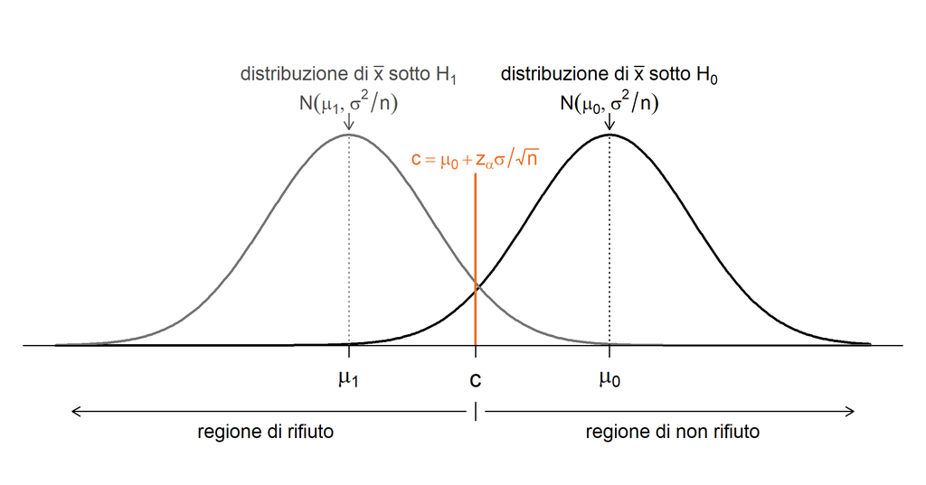

- **regione di rifiuto**: i valori di $\bar{x}$ per cui si rifiuta $H_0$ ($\bar{x} < c$)
- **regione di non rifiuto** (detta anche di accettazione): i valori di $\bar{x}$ per cui non si rifiuta $H_0$ ($\bar{x} \geq c$)

Se $\bar{x}<\mu_0+z_{\alpha}\frac{\sigma}{\sqrt{n}}$ si rifiuta $H_0$;

altrimenti non si rifiuta.

## Test: esempio

- Caso studio
- Con $\alpha = 0.05$
- Con $\alpha = 0.01$
- Usando z

##### stato socioeconomico e peso alla nascita

Le madri con un livello socioeconomico basso partoriscono figli che pesano meno del normale?

- campione: 100 nati vivi consecutivi in un ospedale di una zona svantaggiata, peso medio $\bar{x} = 115$ oz
- riferimento (registro nazionale USA): $\mu_0 = 120$ oz, con $\sigma = 25$ oz nota

$H_0: \mu = 120$, $H_1: \mu < 120$

La deviazione standard del campione (24 oz) qui non serve: $\sigma$ è nota.

$z_{0.05}=-1.645$, quindi il valore critico è

$$c=120-1.645\frac{25}{\sqrt{100}}=115.89$$

$\bar{x}=115<115.89=c$: si rifiuta $H_0$ al livello 0.05.

$z_{0.01}=-2.326$, quindi il valore critico è

$$c=120-2.326\frac{25}{\sqrt{100}}=114.18$$

$\bar{x}=115\geq 114.18=c$: **non si rifiuta** $H_0$ al livello 0.01.

Un $\alpha$ più piccolo è un criterio più severo: per rifiutare $H_0$ serve una media più lontana da 120.

Invece di confrontare $\bar{x}$ con $c$, si può standardizzare $\bar{x}$:

$$z=\frac{\bar{x}-\mu_0}{\frac{\sigma}{\sqrt{n}}}=\frac{115-120}{\frac{25}{\sqrt{100}}}=-2.00$$

Se $z<z_{\alpha}$ si rifiuta $H_0$; altrimenti non si rifiuta.

Con $\alpha = 0.05$: $-2.00 < -1.645$, si rifiuta. Con $\alpha = 0.01$: $-2.00 \geq -2.326$, non si rifiuta. Le conclusioni sono le stesse.

## Test: una o due code

$H_0: \mu = \mu_0$, con $\sigma$ nota e $z=\frac{\bar{x}-\mu_0}{\frac{\sigma}{\sqrt{n}}}$.

- Tre alternative
- Due code
- Graficamente

La regione di rifiuto sta dalla parte verso cui punta $H_1$:

| $H_1$ | si rifiuta $H_0$ se | test |
| --- | --- | --- |
| $\mu < \mu_0$ | $z < z_{\alpha}$ | una coda (sinistra) |
| $\mu > \mu_0$ | $z > z_{1-\alpha}$ | una coda (destra) |
| $\mu \neq \mu_0$ | $z < z_{\frac{\alpha}{2}}$ oppure $z > z_{1-\frac{\alpha}{2}}$ | due code |

Altrimenti non si rifiuta $H_0$.

Con $H_1: \mu \neq \mu_0$ si rifiuta $H_0$ se $z$ è **troppo piccolo o troppo grande**, cioè fuori da due valori critici per $z$, $c_1 < c_2$. I due eventi sono incompatibili, quindi

$$P(\mbox{rifiuto}\ H_0 \mid H_0)=P(Z< c_1 \cup Z> c_2 \mid H_0)=P(Z< c_1 \mid H_0)+P(Z> c_2 \mid H_0)=\alpha$$

Si divide $\alpha$ a metà fra le due code:

$$P(Z< c_1 \mid H_0)=P(Z> c_2 \mid H_0)=\frac{\alpha}{2}$$

quindi $c_1 = z_{\frac{\alpha}{2}} = -z_{1-\frac{\alpha}{2}}$ e $c_2 = z_{1-\frac{\alpha}{2}}$ (con $\alpha = 0.05$: $\pm 1.96$).

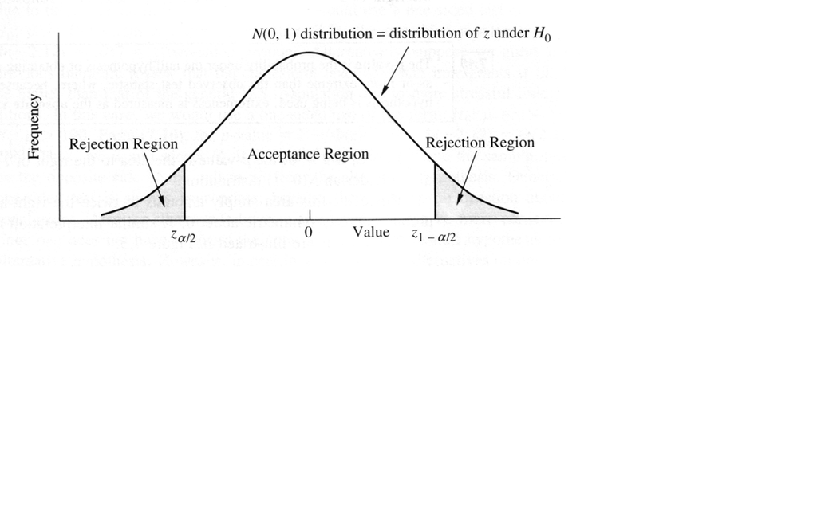

## Test a due code: esempio

##### Colesterolo negli immigrati asiatici

Nelle donne americane fra i 20 e i 40 anni il colesterolo è distribuito normalmente con media $190\ mg/dL$ e deviazione standard $40\ mg/dL$. Le donne asiatiche immigrate della stessa età hanno lo stesso livello medio?

- campione: 100 donne asiatiche, colesterolo medio $\bar{x} = 181.52\ mg/dL$; $\sigma = 40$ nota
- $H_0:\mu=190$, $H_1:\mu\neq 190$ (una differenza in un verso o nell’altro)

$$z=\frac{\bar{x}-\mu_0}{\frac{\sigma}{\sqrt{n}}}=\frac{181.52-190}{\frac{40}{\sqrt{100}}}=-2.12$$

Al livello 0.05 i valori critici sono $z_{0.025}=-1.96$ e $z_{0.975}=1.96$: $z=-2.12<-1.96$, si rifiuta $H_0$.

## Test: varianza non nota

$\sigma$ non è nota: la si stima con $s$, e al posto di $z$ si usa $t$.

- t di Student
- Regola
- Graficamente
- Esempio

Se $X_1,\ldots,X_n$ sono indipendenti e $N(\mu,\sigma^2)$, quando $H_0: \mu = \mu_0$ è vera

$$t=\frac{\bar{X}-\mu_0}{\frac{s}{\sqrt{n}}} \sim t_{n-1}$$

I valori critici si leggono quindi sulla $t$ di Student con $n-1$ gradi di libertà, invece che sulla $N(0,1)$. A due code:

$$P\left(t<t_{n-1,\frac{\alpha}{2}}\right)=P\left(t>t_{n-1,1-\frac{\alpha}{2}}\right)=\frac{\alpha}{2}, \qquad t_{n-1,\frac{\alpha}{2}}=-t_{n-1,1-\frac{\alpha}{2}}$$

$H_0:\mu=\mu_0$, $H_1:\mu\neq\mu_0$

$$t=\frac{\bar{x}-\mu_0}{\frac{s}{\sqrt{n}}}$$

Se $t<t_{n-1,\frac{\alpha}{2}}$ oppure $t>t_{n-1,1-\frac{\alpha}{2}}$ si rifiuta $H_0$;

altrimenti non si rifiuta.

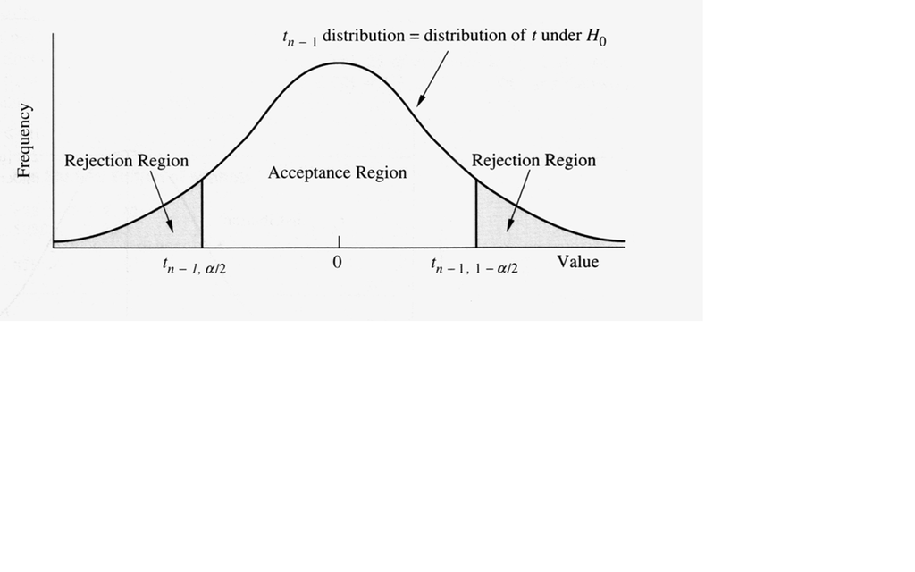

L’esposizione ai fumi cambia il declino della funzione respiratoria nei pompieri?

- campione: 26 pompieri fra 25 e 34 anni; declino in 5 anni del FEV<sub>1</sub> (volume espirato nel primo secondo, letto come litri al secondo): $\bar{x} = 0.27$ L/s, $s = 0.32$ L/s
- nella popolazione generale di pari età il declino medio è 0.10 L/s
- il declino del FEV<sub>1</sub> è distribuito normalmente; $H_0:\mu=0.10$, $H_1:\mu\neq 0.10$

$$t=\frac{\bar{x}-\mu_0}{\frac{s}{\sqrt{n}}}=\frac{0.27-0.10}{\frac{0.32}{\sqrt{26}}}=2.71$$

Al livello 0.05, con $n-1=25$ gradi di libertà, i valori critici sono $\pm t_{25,0.975}=\pm 2.060$: $t=2.71>2.060$, si rifiuta $H_0$.

## Verifica: test z e test t

- Domande
- Risposte

Frequenza cardiaca a riposo: nella popolazione la media è $\mu_0 = 72$ battiti/min, con $\sigma = 12$ nota. In un campione di $n = 36$ pazienti, $\bar{x} = 75.6$.

1. Con $H_1: \mu > 72$, si rifiuta $H_0$ al livello 0.05?
2. E con $H_1: \mu \neq 72$?
3. E se $\sigma$ non fosse nota, e dal campione $s = 12$?

$$z = \frac{75.6 - 72}{\frac{12}{\sqrt{36}}} = \frac{3.6}{2} = 1.80$$

1. Sì: a una coda il valore critico è $z_{0.95} = 1.645$, e $1.80 > 1.645$.
2. No: a due code i valori critici sono $\pm 1.96$, e $-1.96 < 1.80 < 1.96$.

   Con gli stessi dati le conclusioni cambiano: $H_1$ si sceglie prima di guardare i dati.
3. Si usa la $t$ con $n-1=35$ gradi di libertà: $t = \frac{75.6 - 72}{12/\sqrt{36}} = 1.80$. I valori critici sono $t_{35,0.95} = 1.690$ (una coda) e $t_{35,0.975} = 2.030$ (due code): stesse conclusioni di prima, ma con valori critici più grandi di quelli di $z$ (1.645 e 1.96), perché $\sigma$ stimata aggiunge incertezza.

## Richiamo: due p-value già visti

Nella lezione sulle distribuzioni, con la Poisson, si è calcolata la probabilità di osservare **almeno** i casi osservati, se il numero atteso fosse quello della popolazione generale:

| Esempio | Osservati | Attesi | Probabilità | Lettura |
| --- | --- | --- | --- | --- |
| Cibo cancerogeno | 7 morti | 5.8 | $P(X \geq 7) = 0.36$ | nessuna prova di eccesso |
| Tumore al seno | 4 casi su 1000 | 1 | $P(X \geq 4) = 0.019$ | sospetto |

Erano **p-value**: quanto è raro un risultato almeno così estremo, se non succede niente di speciale ($H_0$).

## P-value

- Definizione
- Alternativa minore
- Alternativa maggiore

Il p-value è la probabilità, **se $H_0$ è vera** (e valgono le altre ipotesi del modello: campione casuale, normalità o $n$ grande, $\sigma$ nota), di ottenere un risultato **uguale o più estremo** di quello osservato.

Si rifiuta $H_0$ al livello $\alpha$ se e solo se $p < \alpha$. In questo caso il risultato si dice **statisticamente significativo** al livello $\alpha$.

$H_1:\mu<\mu_0$

«Più estremo» vuol dire più piccolo: il p-value è l’area a sinistra di $z$

$$p=\Phi(z)$$

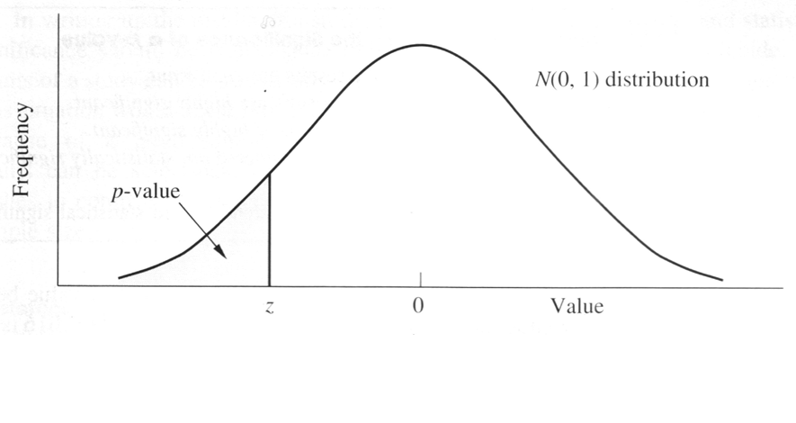

$H_1:\mu>\mu_0$

«Più estremo» vuol dire più grande: il p-value è l’area a destra di $z$

$$p=1-\Phi(z)$$

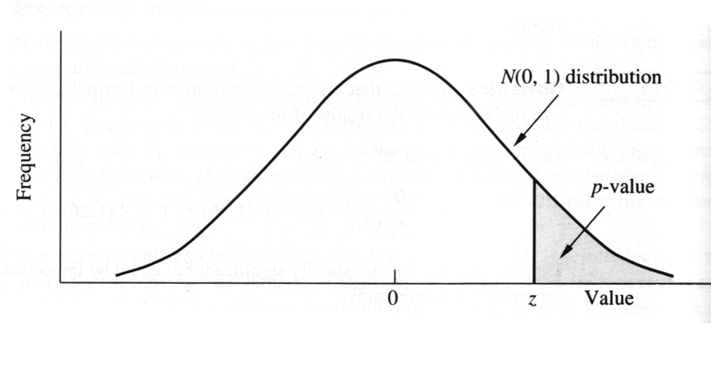

## p-value: esempio

In un campione di 10 bambini il colesterolo medio è $200\ mg/dL$, con deviazione standard nota nella popolazione $\sigma = 50\ mg/dL$. Il colesterolo di questi bambini è più alto del normale ($175\ mg/dL$)? Si usa $\alpha = 0.05$.

$H_0:\mu=175$, $H_1:\mu>175$

$$z=\frac{\bar{x}-\mu_0}{\frac{\sigma}{\sqrt{n}}}=\frac{200-175}{\frac{50}{\sqrt{10}}}=1.58$$

$$p=1-\Phi(1.58)=1-0.9429=0.057$$

$p = 0.057 > 0.05$: non si rifiuta $H_0$. È la stessa conclusione del confronto con il valore critico: $z = 1.58 < z_{0.95} = 1.645$.

## Test a due code: p-value

- Derivazione
- Graficamente
- Esempio
- Con la t

Con $H_1: \mu \neq \mu_0$ sono «più estremi» i valori di $z$ lontani da 0 da entrambe le parti: il p-value è il doppio dell’area oltre $z$, dalla parte in cui cade $z$.

$$p=\left\{\begin{matrix}2\Phi(z) & se & z\leq 0\\ 2[1-\Phi(z)] & se & z>0\end{matrix}\right.$$

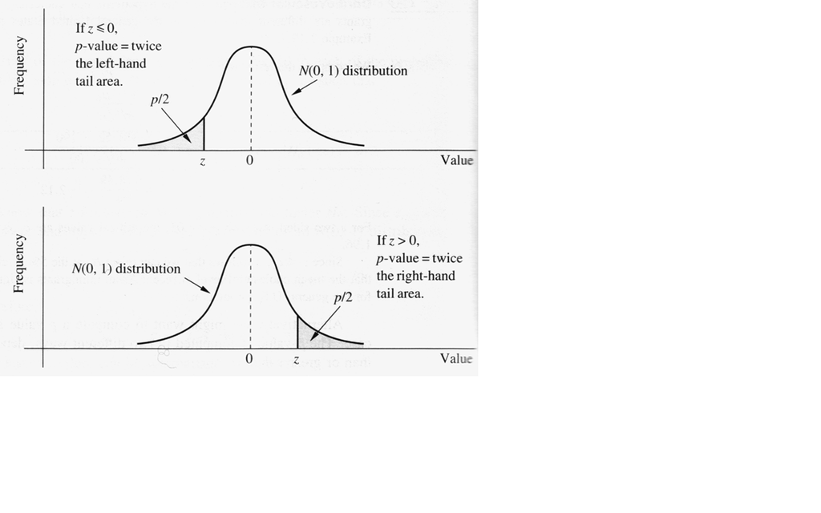

###### Colesterolo negli immigrati asiatici

$z=-2.12 \leq 0$, quindi

$$p=2\Phi(-2.12)=2[1-\Phi(2.12)]=2[1-0.983]=0.034$$

$p = 0.034 < 0.05$: si rifiuta $H_0$, come con i valori critici.

###### Pompieri e FEV<sub>1</sub> (test t)

$t = 2.71$ con 25 gradi di libertà: le aree si leggono sulla $t_{25}$ invece che sulla $N(0,1)$.

Dalle tavole: $t_{25,0.99} = 2.485 < 2.71 < 2.787 = t_{25,0.995}$, quindi $0.005 < P(t_{25}>2.71) < 0.01$ e $0.01 < p < 0.02$ (con un software: $p = 0.012$).

$p < 0.02 < 0.05$: si rifiuta $H_0$, come con i valori critici $\pm 2.060$.

## P-value e IC

- Relazione
- Esempio
- Colesterolo e familiarità

Test a due code con $\sigma$ nota: $H_0:\mu=\mu_0$, $H_1:\mu\neq\mu_0$.

Al livello $\alpha$, $H_0$ è rifiutata **se e solo se** l’IC al livello $(1-\alpha)$ per $\mu$ non contiene $\mu_0$.

Detto con il p-value: $p < \alpha$ se e solo se $\mu_0$ è fuori dall’IC al livello $1-\alpha$.

L’IC al livello $1-\alpha$ contiene quindi i valori di $\mu_0$ che il test al livello $\alpha$ non rifiuta.

#### Colesterolo nei bambini

Un intervallo di confidenza al 95% per la media $\mu$ è pari a

$$\bar{x}-z_{1-\frac{\alpha}{2}}\frac{\sigma}{\sqrt{n}}; \bar{x}+z_{1-\frac{\alpha}{2}}\frac{\sigma}{\sqrt{n}}$$

ovvero

$$\left(200-z_{0.975}\frac{50}{\sqrt{10}};\ 200+z_{0.975}\frac{50}{\sqrt{10}}\right)=(169.01; 230.99)$$

che contiene $\mu_0=175$: con il test a due code non si rifiuta $H_0$ ($z=1.58<1.96$, $p=0.114$).

Si torna al problema d’apertura: $n = 100$ figli, $\bar{x} = 207.2$, $\sigma = 30$ nota; $H_0: \mu = 175$, $H_1: \mu > 175$ (slide «Ipotesi: definizioni»).

$$z = \frac{207.2 - 175}{\frac{30}{\sqrt{100}}} = 10.73$$

p-value $= 1-\Phi(10.73) < 0.0001$: se la media vera fosse 175, una media campionaria di 207.2 o più sarebbe quasi impossibile, e si rifiuta $H_0$. L’IC al 95%, (201.32; 213.08), dice anche quanto: la media dei figli sta fra 26 e 38 mg/dL sopra 175.

## Leggere un p-value: che cosa misura

Il p-value è una probabilità **dei dati, se $H_0$ è vera**:

$$p = P(\mbox{dati almeno così estremi} \mid H_0)$$

**Non** è la probabilità che $H_0$ sia vera, dati i risultati: $p \neq P(H_0 \mid \mbox{dati})$.

È la stessa inversione dei test di screening: la probabilità di un test positivo in un sano non è la probabilità di essere sano dato un test positivo.

$$P(\mbox{test}^+ \mid \mbox{sano}) \neq P(\mbox{sano} \mid \mbox{test}^+)$$

> $p = 0.03$ non vuol dire «3% di probabilità che $H_0$ sia vera».

## Leggere un p-value: se non è significativo

$p > 0.05$ **non** vuol dire «nessun effetto».

Colesterolo in 10 bambini (slide «p-value: esempio»): non si rifiuta $H_0: \mu = 175$, né a una coda ($p = 0.057$) né a due code ($p = 0.114$).

L’IC al 95%, però, è (169.01; 230.99): arriva fino a 56 mg/dL sopra 175. I dati sono compatibili sia con nessuna differenza sia con una differenza grande: con 10 bambini non si riesce a distinguere.

> Assenza di prove non è prova di assenza.

## Leggere un p-value: se è significativo

$p < 0.05$ **non** vuol dire «effetto importante».

Trigliceridi (slide «IC osservazioni: ampiezza»): con $\sigma = 20$ e $n = 1000$ l’IC al 95% è largo 2.5 mg/dL. Basta che la media del campione disti da $\mu_0$ più di 1.24 mg/dL perché il test a due code dia $p < 0.05$: una differenza minima, senza peso clinico, diventa «significativa».

Il p-value non dice quanto è grande l’effetto. Si legge l’**IC**: dice quanto è grande l’effetto e quanto siamo incerti.

> 0.05 è una convenzione: $p = 0.049$ e $p = 0.051$ dicono la stessa cosa.

## Sondaggio

Per me: [p-value](https://app.wooclap.com/events/STATMEDPVALUE/0)

Per voi:

[figure not shown]

bit.ly/statmed-sondaggio-pvalue

## Mappa: Test d’ipotesi

- Mappa
- Indice

```
%%{init: {"htmlLabels": false, "flowchart": {"padding": 12, "wrappingWidth": 320}, "themeVariables": {"fontFamily": "Arial, Helvetica, sans-serif"}}}%%
flowchart LR
  n_distribuzione_campionaria["Distribuzione campionaria"]:::prev
  n_errore_standard["Errore standard"]:::prev
  n_stimatore["Stimatore"]:::prev
  n_ic_media_varianza_nota["IC, σ nota"]:::prev
  n_ampiezza_dell_intervallo_di_confidenza["Ampiezza dell'IC"]:::prev
  n_ic_a_livello_generico["IC a livello 1−α"]:::prev
  n_interpretazione_dell_intervallo_di_confidenza["Interpretazione dell'IC"]:::prev
  n_distribuzione_t_di_student["t di Student"]:::prev
  n_gradi_di_liberta["Gradi di libertà"]:::prev
  n_percentile_della_t_di_student["Percentili di t"]:::prev
  k_n_03_condizionata["Probabilità condizionata · 03"]:::prev
  k_n_03_operazioni["Operazioni fra eventi · 03"]:::prev
  k_n_03_probabilita["Probabilità · 03"]:::prev
  k_n_03_somma_prodotto["Somma, prodotto, indipendenza · 03"]:::prev
  k_n_03_test["Test diagnostici · 03"]:::prev
  k_n_04_massa["Massa e cumulata · 04"]:::prev
  k_n_04_parametri["Parametri e statistiche · 04"]:::prev
  k_n_04_poisson["Poisson · 04"]:::prev
  k_n_04_tavole["Tavole e standardizzazione · 04"]:::prev
  n_confronto_tra_ic_e_valore_di_riferimento["IC e valore di riferimento"]:::cur
  n_ipotesi_nulla["Ipotesi nulla H₀"]:::cur
  n_ipotesi_alternativa["Ipotesi alternativa H₁"]:::cur
  n_test_d_ipotesi["Test d'ipotesi"]:::cur
  n_rifiuto_e_non_rifiuto_di_h0["Rifiutare H₀ o no"]:::cur
  n_errore_di_primo_tipo["Errore di I tipo"]:::cur
  n_errore_di_secondo_tipo["Errore di II tipo"]:::cur
  n_significativita_statistica["Significatività α"]:::cur
  n_potenza["Potenza 1−β"]:::cur
  n_statistica_test["Statistica test"]:::cur
  n_valore_critico["Valore critico"]:::cur
  n_regione_di_rifiuto["Regione di rifiuto"]:::cur
  n_test_sulla_media_varianza_nota["Test sulla media, σ nota"]:::cur
  n_statistica_z_del_test["Statistica z"]:::cur
  n_p_value["p-value"]:::cur
  n_calcolo_del_p_value["Calcolo del p-value"]:::cur
  n_test_a_una_coda["Test a una coda"]:::cur
  n_test_a_due_code["Test a due code"]:::cur
  n_p_value_a_due_code["p-value a due code"]:::cur
```

[output cut: 39 more lines]

```
  n_rifiuto_e_non_rifiuto_di_h0 --> n_errore_di_primo_tipo
  n_rifiuto_e_non_rifiuto_di_h0 --> n_errore_di_secondo_tipo
  n_significativita_statistica --> n_valore_critico
  n_statistica_test --> n_valore_critico
  n_statistica_z_del_test --> n_p_value
  n_statistica_z_del_test --> n_test_a_una_coda
  n_stimatore --> n_statistica_test
  n_test_a_due_code --> n_test_t_per_la_media
  n_test_a_una_coda --> n_test_a_due_code
  n_test_sulla_media_varianza_nota --> n_statistica_z_del_test
  n_test_t_per_la_media --> n_p_value_a_due_code
  n_valore_critico --> n_regione_di_rifiuto
  classDef cur fill:#e6f0fa,stroke:#035AA6,color:#000000
  classDef prev fill:#f4f4f4,stroke:#9a9a9a,color:#555555,stroke-dasharray:4 3
  classDef opt fill:#ffffff,stroke:#035AA6,color:#555555,stroke-dasharray:2 2
```

Ogni freccia va da un concetto a quelli che lo usano. In grigio i concetti delle sezioni o dei deck precedenti (con il numero del deck).

- IC e valore di riferimento
- Ipotesi nulla H₀
- Ipotesi alternativa H₁
- Test d’ipotesi
- Rifiutare H₀ o no
- Errore di I tipo
- Errore di II tipo
- Significatività α
- Potenza 1−β
- Statistica test
- Valore critico
- Regione di rifiuto
- Test sulla media, σ nota
- Statistica z
- p-value
- Calcolo del p-value
- Test a una coda
- Test a due code
- p-value a due code
- Test t sulla media
- Test e IC
- p-value non è P(H₀)
- Non significativo ≠ nessun effetto
- Significativo ≠ importante

## Mappa: tutte le sezioni

- Mappa
- Blocchi

```
%%{init: {"htmlLabels": false, "flowchart": {"padding": 12, "wrappingWidth": 320}, "themeVariables": {"fontFamily": "Arial, Helvetica, sans-serif"}}}%%
flowchart LR
  k_n_02_centralita["Centralità · 02"]:::prev
  k_n_02_notazioni["Indici e sommatoria · 02"]:::prev
  k_n_02_percentili["Percentili e quartili · 02"]:::prev
  k_n_02_unita["Unità, variabili, tabelle · 02"]:::prev
  k_n_02_variabilita["Variabilità · 02"]:::prev
  k_n_03_condizionata["Probabilità condizionata · 03"]:::prev
  k_n_03_operazioni["Operazioni fra eventi · 03"]:::prev
  k_n_03_probabilita["Probabilità · 03"]:::prev
  k_n_03_somma_prodotto["Somma, prodotto, indipendenza · 03"]:::prev
  k_n_03_test["Test diagnostici · 03"]:::prev
  k_n_04_massa["Massa e cumulata · 04"]:::prev
  k_n_04_momenti["Valore atteso e varianza · 04"]:::prev
  k_n_04_normale["Normale · 04"]:::prev
  k_n_04_parametri["Parametri e statistiche · 04"]:::prev
  k_n_04_poisson["Poisson · 04"]:::prev
  k_n_04_tavole["Tavole e standardizzazione · 04"]:::prev
  k_n_04_vc["Variabili casuali · 04"]:::prev
  k_n_05_campioni["Inferenza e campioni (5)"]:::cur
  k_n_05_stima["Stima puntuale (4)"]:::cur
  k_n_05_media_campionaria["Distribuzione della media (5)"]:::cur
  k_n_05_ic["Intervallo di confidenza (8)"]:::cur
  k_n_05_t["t di Student (4)"]:::cur
  k_n_05_ipotesi["Ipotesi ed errori (9)"]:::cur
  k_n_05_test_z["Test z e test t (8)"]:::cur
  k_n_05_p_value["P-value (7)"]:::cur
  k_n_02_centralita --> k_n_05_stima
  k_n_02_notazioni --> k_n_05_stima
  k_n_02_percentili --> k_n_05_t
  k_n_02_unita --> k_n_05_campioni
  k_n_02_unita --> k_n_05_stima
  k_n_02_variabilita --> k_n_05_media_campionaria
  k_n_03_condizionata --> k_n_05_ipotesi
  k_n_03_operazioni --> k_n_05_test_z
  k_n_03_probabilita --> k_n_05_campioni
  k_n_03_somma_prodotto --> k_n_05_campioni
  k_n_03_test --> k_n_05_p_value
  k_n_04_massa --> k_n_05_campioni
  k_n_04_momenti --> k_n_05_stima
  k_n_04_normale --> k_n_05_media_campionaria
  k_n_04_parametri --> k_n_05_stima
  k_n_04_poisson --> k_n_05_p_value
  k_n_04_tavole --> k_n_05_ic
  k_n_04_vc --> k_n_05_stima
  k_n_05_campioni --> k_n_05_media_campionaria
  k_n_05_ic --> k_n_05_ipotesi
  k_n_05_ic --> k_n_05_t
  k_n_05_ipotesi --> k_n_05_test_z
  k_n_05_media_campionaria --> k_n_05_ic
  k_n_05_stima --> k_n_05_media_campionaria
  k_n_05_t --> k_n_05_test_z
  k_n_05_test_z --> k_n_05_p_value
  classDef cur fill:#e6f0fa,stroke:#035AA6,color:#000000
  classDef prev fill:#f4f4f4,stroke:#9a9a9a,color:#555555,stroke-dasharray:4 3
  classDef opt fill:#ffffff,stroke:#035AA6,color:#555555,stroke-dasharray:2 2
```

Ogni freccia va da un concetto a quelli che lo usano. Ogni riquadro è un blocco di concetti che si usano insieme; fra parentesi quanti sono.

- **Inferenza e campioni**: Inferenza, Campione casuale, Campione casuale semplice, Popolazione target, Campione rappresentativo
- **Stima puntuale**: Stima puntuale, Stimatore, Stimatore non distorto, Numerosità n
- **Distribuzione della media**: Distribuzione campionaria, Var(aX), Varianza della media, Errore standard, Limite centrale
- **Intervallo di confidenza**: Intervallo di confidenza, Derivazione dell’IC, IC, σ nota, Livello di confidenza, Interpretazione dell’IC, IC a livello 1−α, Ampiezza dell’IC, Precisione delle misure
- **t di Student**: t di Student, Gradi di libertà, Percentili di t, IC, σ ignota
- **Ipotesi ed errori**: IC e valore di riferimento, Ipotesi nulla H₀, Ipotesi alternativa H₁, Test d’ipotesi, Rifiutare H₀ o no, Errore di I tipo, Errore di II tipo, Significatività α, Potenza 1−β
- **Test z e test t**: Statistica test, Valore critico, Regione di rifiuto, Test sulla media, σ nota, Statistica z, Test a una coda, Test a due code, Test t sulla media
- **P-value**: p-value, Calcolo del p-value, p-value a due code, Test e IC, p-value non è P(H₀), Non significativo ≠ nessun effetto, Significativo ≠ importante

## Risorse utili

- *Fundamentals of Biostatistics* (8ª ed., Cengage, 2016) di **Bernard Rosner**, suggeriti i capitoli 6 e 7.
- Wasserstein RL, Lazar NA. [**The ASA Statement on p-Values: Context, Process, and Purpose**](https://doi.org/10.1080/00031305.2016.1154108). *The American Statistician* 2016;70(2):129-133.
- Greenland S, Senn SJ, Rothman KJ, Carlin JB, Poole C, Goodman SN, Altman DG. [**Statistical tests, P values, confidence intervals, and power: a guide to misinterpretations**](https://doi.org/10.1007/s10654-016-0149-3). *European Journal of Epidemiology* 2016;31:337-350.

*Mathematical conventions are just that, conventions. They differ by field of mathematics. Don’t ask us why **matrix rows** **are numbered down** but **graphs** **are numbered up** the **y axis**, nor why **x comes before y** but **row before column**. But the matrix layout has always seemed illogical to me.*

—Brian D. Ripley  
08/2004 - R-help

### **Grazie** per l’attenzione!

Diapositive: bit.ly/cl-statmed

[**www.unipd-ubep.it**](https://www.unipd-ubep.it/) | **Corrado.Lanera@ubep.unipd.it**

**@CorradoLanera** | [**bit.ly/statmed-cl-ricevimento**](https://bit.ly/statmed-cl-ricevimento)